# ppatil8_hw4

Prachi Vijay Patil

2023-10-30

### Lab

#5.3

#Cross-Validation and the Bootstrap

#The valid Set Approach

```r
library(ISLR2)
set.seed(1)
train <- sample(392, 196)
lm.fit <- lm(mpg ~ horsepower, data = Auto, subset = train)
attach(Auto)
mean((mpg - predict(lm.fit , Auto))[-train]^2)
```

```
## [1] 23.26601
```

```r
lm.fit2 <- lm(mpg ~ poly(horsepower, 2), data = Auto, subset = train)
mean((mpg - predict(lm.fit2, Auto))[-train]^2)
```

```
## [1] 18.71646
```

```r
lm.fit3 <- lm(mpg ~ poly(horsepower, 3), data = Auto, subset = train)
mean((mpg - predict(lm.fit3, Auto))[-train]^2)
```

```
## [1] 18.79401
```

```r
set.seed(2)
train <- sample(392, 192)
lm.fit <- lm(mpg ~ horsepower, subset = train)
mean((mpg - predict(lm.fit,Auto))[-train]^2)
```

```
## [1] 25.47719
```

```r
lm.fit2 <- lm(mpg ~ poly(horsepower, 2), data = Auto, subset = train)
mean((mpg - predict(lm.fit2, Auto))[-train]^2)
```

```
## [1] 20.41973
```

```r
lm.fit3 <- lm(mpg ~ poly(horsepower, 3), data = Auto, subset = train)
mean((mpg - predict(lm.fit3, Auto))[-train]^2)
```

```
## [1] 20.38552
```

#Leave-One-Out Cross-Validation

```r
glm.fit <- glm(mpg ~ horsepower, data = Auto)
coef(glm.fit)
```

```
## (Intercept)  horsepower
##  39.9358610  -0.1578447
```

```r
lm.fit <- lm(mpg ~ horsepower, data = Auto)
coef(lm.fit)
```

```
## (Intercept)  horsepower
##  39.9358610  -0.1578447
```

```r
library(boot)
glm.fit <- glm(mpg ~ horsepower, data = Auto)
cv.err <- cv.glm(Auto, glm.fit)
cv.err$delta
```

```
## [1] 24.23151 24.23114
```

```r
cv.error <- rep(0, 10)
for(i in 1:10){
  glm.fit <- glm(mpg ~ poly(horsepower, i), data = Auto)
  cv.error[i] <- cv.glm(Auto, glm.fit)$delta[1]
}
cv.error
```

```
##  [1] 24.23151 19.24821 19.33498 19.42443 19.03321 18.97864 18.83305 18.96115
##  [9] 19.06863 19.49093
```

#k-Fold Cross-Validation

```r
set.seed(17)
cv.error.10 <- rep(0, 10)
for(i in 1:10){
  glm.fit <- glm(mpg ~ poly(horsepower, i), data = Auto)
  cv.error.10[i] <- cv.glm(Auto, glm.fit, K = 10)$delta[1]
}
cv.error.10
```

```
##  [1] 24.27207 19.26909 19.34805 19.29496 19.03198 18.89781 19.12061 19.14666
##  [9] 18.87013 20.95520
```

#The Bootstrap

```r
alpha.fn <- function(data, index){
  X <- data$X[index]
  Y <- data$Y[index]
  (var(Y) - cov(X, Y)) / (var(X) + var(Y) - 2* cov(X, Y))
}
alpha.fn(Portfolio, 1:100)
```

```
## [1] 0.5758321
```

```r
set.seed(7)
alpha.fn(Portfolio, sample(100, 100, replace = T))
```

```
## [1] 0.5385326
```

```r
boot(Portfolio, alpha.fn, R = 1000)
```

```
##
## ORDINARY NONPARAMETRIC BOOTSTRAP
##
##
## Call:
## boot(data = Portfolio, statistic = alpha.fn, R = 1000)
##
##
## Bootstrap Statistics :
##      original       bias    std. error
## t1* 0.5758321 0.0007959475  0.08969074
```

```r
boot.fn <- function(data, index)
coef(lm(mpg ~ horsepower, data = data, subset = index))
boot.fn(Auto, 1:392)
```

```
## (Intercept)  horsepower
##  39.9358610  -0.1578447
```

```r
set.seed(1)
boot.fn(Auto, sample(392, 392, replace = T))
```

```
## (Intercept)  horsepower
##  40.3404517  -0.1634868
```

```r
boot.fn(Auto, sample(392, 392, replace = T))
```

```
## (Intercept)  horsepower
##  40.1186906  -0.1577063
```

```r
boot(Auto, boot.fn, 1000)
```

```
##
## ORDINARY NONPARAMETRIC BOOTSTRAP
##
##
## Call:
## boot(data = Auto, statistic = boot.fn, R = 1000)
##
##
## Bootstrap Statistics :
##       original        bias    std. error
## t1* 39.9358610  0.0544513229 0.841289790
## t2* -0.1578447 -0.0006170901 0.007343073
```

```r
summary(lm(mpg ~ horsepower, data = Auto))$coef
```

```
##               Estimate  Std. Error   t value      Pr(>|t|)
## (Intercept) 39.9358610 0.717498656  55.65984 1.220362e-187
## horsepower  -0.1578447 0.006445501 -24.48914  7.031989e-81
```

```r
boot.fn <- function(data, index)
coef(
  lm(mpg ~ horsepower + I(horsepower^2),
     data = data, subset = index)
)
set.seed(1)
boot(Auto, boot.fn, 1000)
```

```
##
## ORDINARY NONPARAMETRIC BOOTSTRAP
##
##
## Call:
## boot(data = Auto, statistic = boot.fn, R = 1000)
##
##
## Bootstrap Statistics :
##         original        bias     std. error
## t1* 56.900099702  3.511640e-02 2.0300222526
## t2* -0.466189630 -7.080834e-04 0.0324241984
## t3*  0.001230536  2.840324e-06 0.0001172164
```

```r
summary(
  lm(mpg ~ horsepower + I(horsepower^2), data = Auto)
)$coef
```

```
##                     Estimate   Std. Error   t value      Pr(>|t|)
## (Intercept)     56.900099702 1.8004268063  31.60367 1.740911e-109
## horsepower      -0.466189630 0.0311246171 -14.97816  2.289429e-40
## I(horsepower^2)  0.001230536 0.0001220759  10.08009  2.196340e-21
```

#7.8.3

#GAMs

```r
library(splines)
gam1 <- lm(wage ~ ns(year, 4) + ns(age, 5) + education, data = Wage)
library(gam)
```

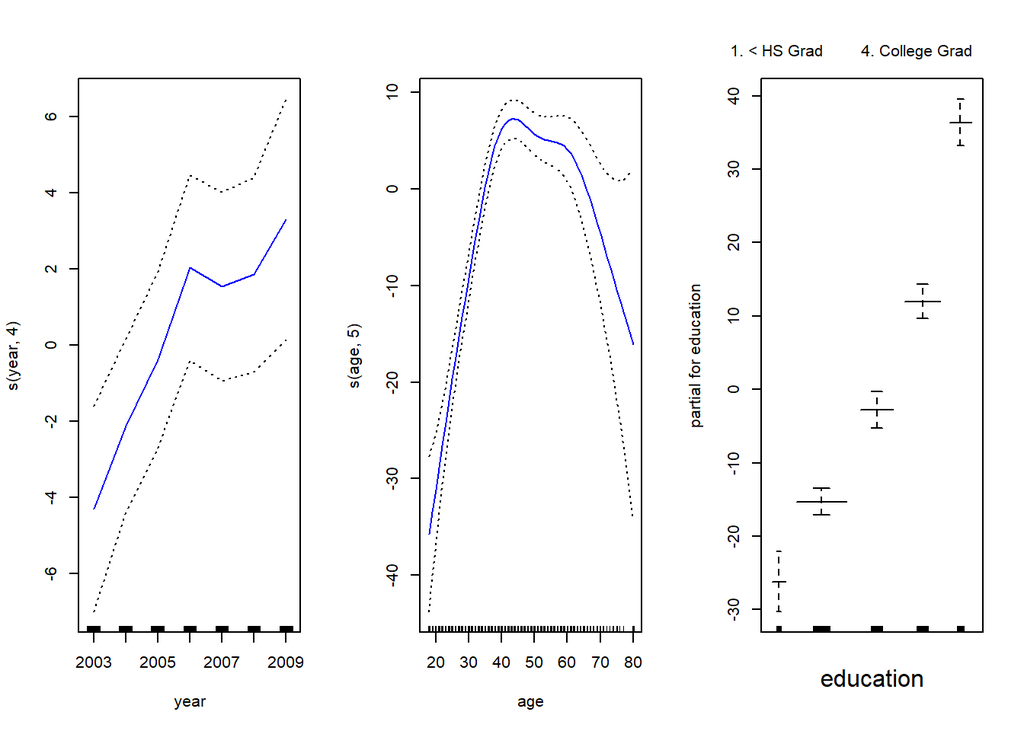

```r
gam.m3 <- gam(wage ~ s(year, 4) + s(age, 5) + education, data = Wage)
par(mfrow = c(1, 3))
plot(gam.m3, se = TRUE, col = "blue")
```

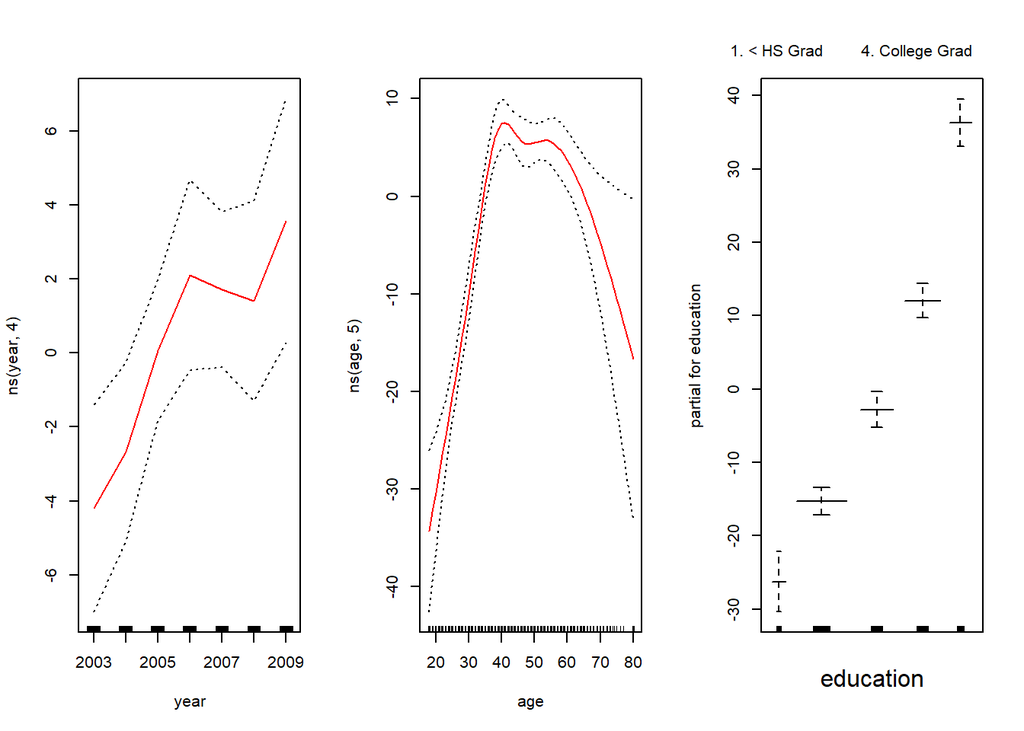

```r
plot.Gam(gam1, se = TRUE, col = "red")
```

```r
gam.m1 <- gam(wage ~ s(age, 5) + education, data = Wage)
gam.m2 <- gam(wage ~ year + s(age, 5) + education, data = Wage)
anova(gam.m1, gam.m2, gam.m3, test = "F")
```

```
## Analysis of Deviance Table
##
## Model 1: wage ~ s(age, 5) + education
## Model 2: wage ~ year + s(age, 5) + education
## Model 3: wage ~ s(year, 4) + s(age, 5) + education
##   Resid. Df Resid. Dev Df Deviance       F    Pr(>F)
## 1      2990    3711731
## 2      2989    3693842  1  17889.2 14.4771 0.0001447 ***
## 3      2986    3689770  3   4071.1  1.0982 0.3485661
## ---
## Signif. codes:  0 '***' 0.001 '**' 0.01 '*' 0.05 '.' 0.1 ' ' 1
```

```r
summary(gam.m3)
```

```
##
## Call: gam(formula = wage ~ s(year, 4) + s(age, 5) + education, data = Wage)
## Deviance Residuals:
##     Min      1Q  Median      3Q     Max
## -119.43  -19.70   -3.33   14.17  213.48
##
## (Dispersion Parameter for gaussian family taken to be 1235.69)
##
##     Null Deviance: 5222086 on 2999 degrees of freedom
## Residual Deviance: 3689770 on 2986 degrees of freedom
## AIC: 29887.75
##
## Number of Local Scoring Iterations: NA
##
## Anova for Parametric Effects
##              Df  Sum Sq Mean Sq F value    Pr(>F)
## s(year, 4)    1   27162   27162  21.981 2.877e-06 ***
## s(age, 5)     1  195338  195338 158.081 < 2.2e-16 ***
## education     4 1069726  267432 216.423 < 2.2e-16 ***
## Residuals  2986 3689770    1236
## ---
## Signif. codes:  0 '***' 0.001 '**' 0.01 '*' 0.05 '.' 0.1 ' ' 1
##
## Anova for Nonparametric Effects
##             Npar Df Npar F  Pr(F)
## (Intercept)
## s(year, 4)        3  1.086 0.3537
## s(age, 5)         4 32.380 <2e-16 ***
## education
## ---
## Signif. codes:  0 '***' 0.001 '**' 0.01 '*' 0.05 '.' 0.1 ' ' 1
```

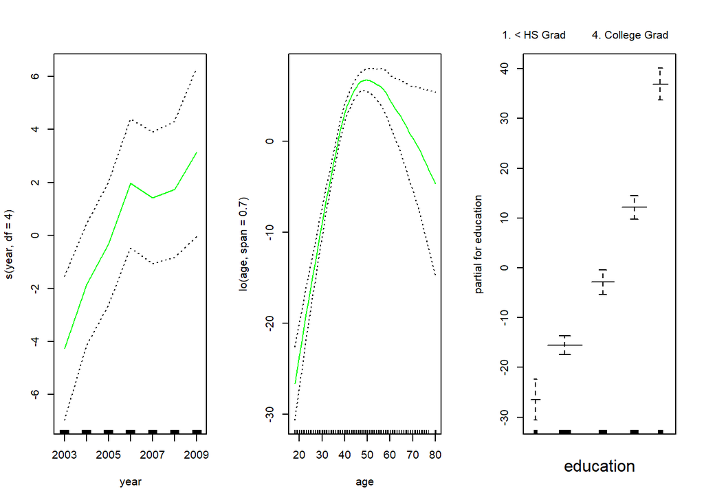

```r
preds <- predict(gam.m2, newdata = Wage)
gam.lo <- gam(
  wage ~ s(year, df = 4) + lo(age, span = 0.7) + education, data = Wage
)
plot.Gam(gam.lo, se = TRUE, col = "green")
gam.lo.i <- gam(wage ~ lo(year, age, span = 0.5) + education, data = Wage)
library(akima)
```

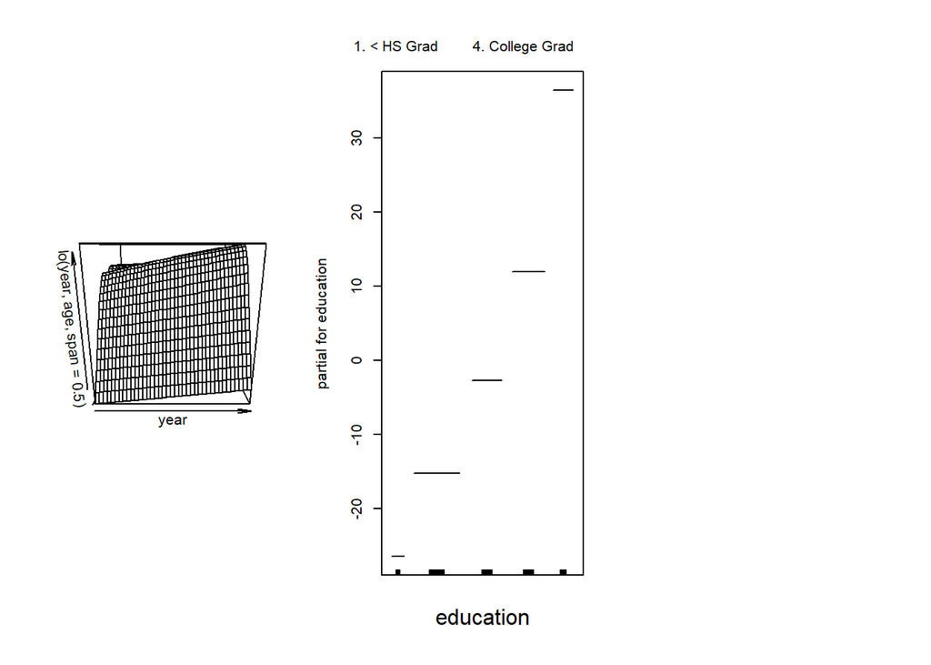

```r
plot(gam.lo.i)
gam.lr <- gam(
  I(wage > 250) ~ year + s(age, df = 5) + education,
  family = binomial, data = Wage
)
par(mfrow = c(1, 3))
```

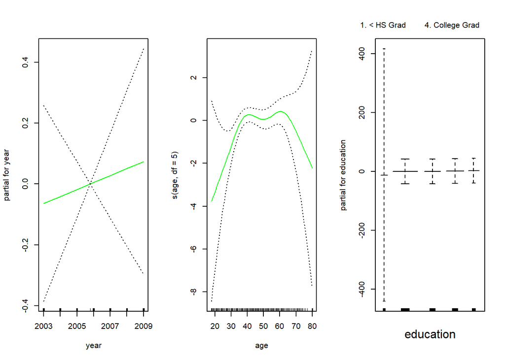

```r
plot(gam.lr, se = T, col = "green")
```

```r
table(Wage$education, I(Wage$wage > 250))
```

```
##
##                      FALSE TRUE
##   1. < HS Grad         268    0
##   2. HS Grad           966    5
##   3. Some College      643    7
##   4. College Grad      663   22
##   5. Advanced Degree   381   45
```

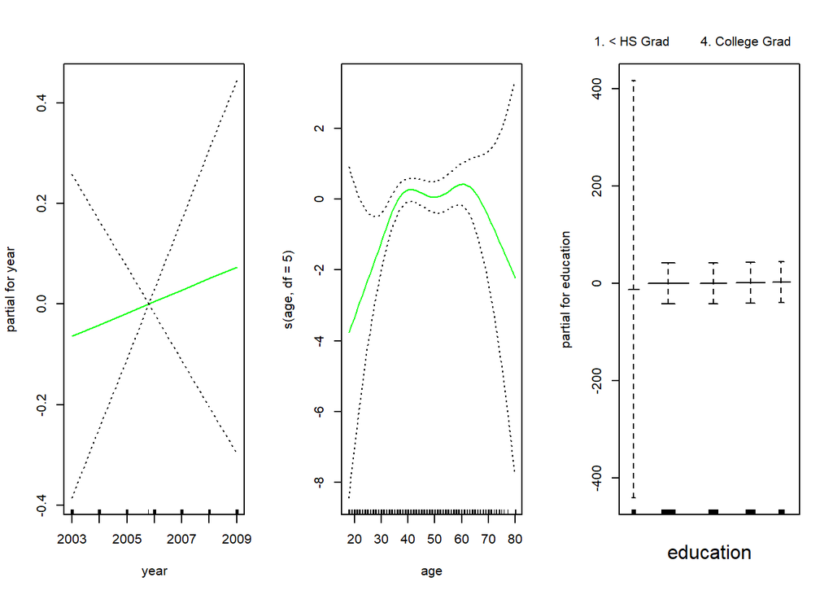

```r
gam.lr.s <- gam(
  I(wage > 250) ~ year + s(age, df = 5) + education,
  family = binomial, data = Wage,
  subset = (education != "i. <HS Grad")
)
plot(gam.lr.s, se = T, col = "green")
```

### Exercise ###

#5.4

#Q8

```r
set.seed(1)
x <- rnorm(100)
y <- x - 2 * x^2 + rnorm(100)
```

#8a:

#In this, the value of n = 100, p = 2

#The model used to generate the data is: Y = X - 2X^2 + e

#8b:

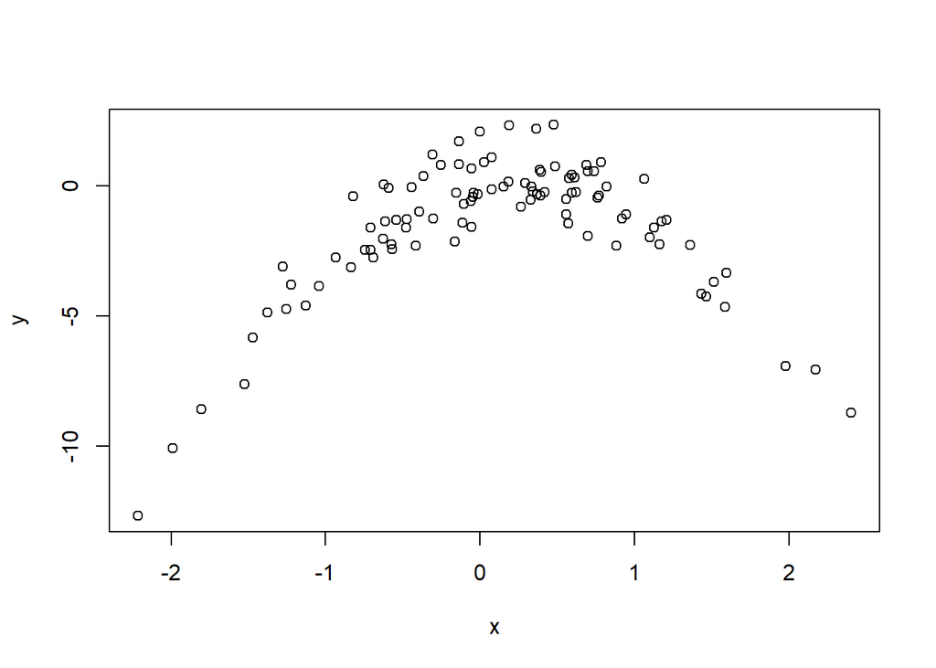

```r
plot(x, y)
```

#8c:

```r
library(boot)
set.seed(10)
Data <- data.frame(x, y)
glm.fit.1 <- glm(y ~ x)
cv.glm(Data, glm.fit.1)$delta[1]
```

```
## [1] 7.288162
```

```r
glm.fit.2 <- glm(y ~ poly(x, 2))
cv.glm(Data, glm.fit.2)$delta[1]
```

```
## [1] 0.9374236
```

```r
glm.fit.3 <- glm(y ~ poly(x, 3))
cv.glm(Data, glm.fit.3)$delta[1]
```

```
## [1] 0.9566218
```

```r
glm.fit.4 <- glm(y ~ poly(x, 4))
cv.glm(Data, glm.fit.4)$delta[1]
```

```
## [1] 0.9539049
```

#The test error for model Y = B0 + B1*X + e is 7.28816

#The test error for model Y = B0 + B1*X + B2*X^2 + e is 0.9374

#The test error for model Y = B0 + B1*X + B2*X^2 + B3*X^3 + e is 0.95662

#The test error for model Y = B0 + B1*X + B2*X^2 + B3*X^3 + B4*X^4+ e is 0.95390

#The test error drastically decreases when we take a model with higher order than 1

#The most efficient model is with the least test error value which is the model with quadratic value of X

#8d:

```r
set.seed(21)
Data <- data.frame(x, y)
glm.fit.1 <- glm(y ~ x)
cv.glm(Data, glm.fit.1)$delta[1]
```

```
## [1] 7.288162
```

```r
glm.fit.2 <- glm(y ~ poly(x, 2))
cv.glm(Data, glm.fit.2)$delta[1]
```

```
## [1] 0.9374236
```

```r
glm.fit.3 <- glm(y ~ poly(x, 3))
cv.glm(Data, glm.fit.3)$delta[1]
```

```
## [1] 0.9566218
```

```r
glm.fit.4 <- glm(y ~ poly(x, 4))
cv.glm(Data, glm.fit.4)$delta[1]
```

```
## [1] 0.9539049
```

#The test error for model Y = B0 + B1*X + e is 7.28816

#The test error for model Y = B0 + B1*X + B2*X^2 + e is 0.9374

#The test error for model Y = B0 + B1*X + B2*X^2 + B3*X^3 + e is 0.95662

#The test error for model Y = B0 + B1*X + B2*X^2 + B3*X^3 + B4*X^4+ e is 0.95390

#The test error drastically decreases when we take a model with higher order than 1

#The most efficient model is with the least test error value which is the model with quadratic value of X

#The result with different seed value is same because with LOOCV, it evaluates each individual value within the sample and calculates the test error and there is no randomness

#Results do not depend on the random seed because all observations are used as holdout

#There is only one LOOCV error statistic

#8e:

#The second model2 Y = B0 + B1 * X + B2 * X^2 + e has the lowest error rate because it has the same structure as the original model y <- x - 2 * x^2 + rnorm(100)

#8f:

```r
summary(glm.fit.1)
```

```
##
## Call:
## glm(formula = y ~ x)
##
## Coefficients:
##             Estimate Std. Error t value Pr(>|t|)
## (Intercept)  -1.6254     0.2619  -6.205 1.31e-08 ***
## x             0.6925     0.2909   2.380   0.0192 *
## ---
## Signif. codes:  0 '***' 0.001 '**' 0.01 '*' 0.05 '.' 0.1 ' ' 1
##
## (Dispersion parameter for gaussian family taken to be 6.760719)
##
##     Null deviance: 700.85  on 99  degrees of freedom
## Residual deviance: 662.55  on 98  degrees of freedom
## AIC: 478.88
##
## Number of Fisher Scoring iterations: 2
```

```r
summary(glm.fit.2)
```

```
##
## Call:
## glm(formula = y ~ poly(x, 2))
##
## Coefficients:
##             Estimate Std. Error t value Pr(>|t|)
## (Intercept)  -1.5500     0.0958  -16.18  < 2e-16 ***
## poly(x, 2)1   6.1888     0.9580    6.46 4.18e-09 ***
## poly(x, 2)2 -23.9483     0.9580  -25.00  < 2e-16 ***
## ---
## Signif. codes:  0 '***' 0.001 '**' 0.01 '*' 0.05 '.' 0.1 ' ' 1
##
## (Dispersion parameter for gaussian family taken to be 0.9178258)
##
##     Null deviance: 700.852  on 99  degrees of freedom
## Residual deviance:  89.029  on 97  degrees of freedom
## AIC: 280.17
##
## Number of Fisher Scoring iterations: 2
```

```r
summary(glm.fit.3)
```

```
##
## Call:
## glm(formula = y ~ poly(x, 3))
##
## Coefficients:
##              Estimate Std. Error t value Pr(>|t|)
## (Intercept)  -1.55002    0.09626 -16.102  < 2e-16 ***
## poly(x, 3)1   6.18883    0.96263   6.429 4.97e-09 ***
## poly(x, 3)2 -23.94830    0.96263 -24.878  < 2e-16 ***
## poly(x, 3)3   0.26411    0.96263   0.274    0.784
## ---
## Signif. codes:  0 '***' 0.001 '**' 0.01 '*' 0.05 '.' 0.1 ' ' 1
##
## (Dispersion parameter for gaussian family taken to be 0.9266599)
##
##     Null deviance: 700.852  on 99  degrees of freedom
## Residual deviance:  88.959  on 96  degrees of freedom
## AIC: 282.09
##
## Number of Fisher Scoring iterations: 2
```

```r
summary(glm.fit.4)
```

```
##
## Call:
## glm(formula = y ~ poly(x, 4))
##
## Coefficients:
##              Estimate Std. Error t value Pr(>|t|)
## (Intercept)  -1.55002    0.09591 -16.162  < 2e-16 ***
## poly(x, 4)1   6.18883    0.95905   6.453 4.59e-09 ***
## poly(x, 4)2 -23.94830    0.95905 -24.971  < 2e-16 ***
## poly(x, 4)3   0.26411    0.95905   0.275    0.784
## poly(x, 4)4   1.25710    0.95905   1.311    0.193
## ---
## Signif. codes:  0 '***' 0.001 '**' 0.01 '*' 0.05 '.' 0.1 ' ' 1
##
## (Dispersion parameter for gaussian family taken to be 0.9197797)
##
##     Null deviance: 700.852  on 99  degrees of freedom
## Residual deviance:  87.379  on 95  degrees of freedom
## AIC: 282.3
##
## Number of Fisher Scoring iterations: 2
```

#From the summary of glm.fit.2, glm.fit.3, and glm.fit.4 models, it is obvious that the linear and quadratic terms have statistical significance

#This agree strongly with our cross-validation results which were minimum for the quadratic model

#This points towards the second model with only linear and quadratic terms being the most efficiant model

#6.6

#Q9

#9a:

```r
set.seed(4)
train_index <- sample(1:nrow(College), round(nrow(College)* 0.75))
train <- College[train_index, ]
nrow(train) / nrow(College)
```

```
## [1] 0.7503218
```

```r
test <- College[-train_index, ]
nrow(test) / nrow(College)
```

```
## [1] 0.2496782
```

#9b:

```r
library(splines)
library(glmnet)
model.full <- lm(Apps ~., data = train)
summary(model.full)
```

```
##
## Call:
## lm(formula = Apps ~ ., data = train)
##
## Residuals:
##     Min      1Q  Median      3Q     Max
## -3363.8  -416.9   -33.9   332.5  6225.4
##
## Coefficients:
##               Estimate Std. Error t value Pr(>|t|)
## (Intercept) -729.76802  433.06011  -1.685 0.092513 .
## PrivateYes  -559.87787  153.60120  -3.645 0.000292 ***
## Accept         1.23426    0.05868  21.032  < 2e-16 ***
## Enroll        -0.26793    0.23262  -1.152 0.249901
## Top10perc     48.09428    6.17471   7.789 3.25e-14 ***
## Top25perc    -12.87660    5.02841  -2.561 0.010703 *
## F.Undergrad    0.12228    0.03823   3.198 0.001461 **
## P.Undergrad   -0.05668    0.04771  -1.188 0.235278
## Outstate      -0.05502    0.02052  -2.681 0.007555 **
## Room.Board     0.21852    0.05350   4.085 5.05e-05 ***
## Books         -0.16931    0.25735  -0.658 0.510878
## Personal      -0.03151    0.06696  -0.471 0.638105
## PhD           -9.22369    5.25238  -1.756 0.079614 .
## Terminal      -3.65729    5.72661  -0.639 0.523311
## S.F.Ratio     15.14171   13.70687   1.105 0.269768
## perc.alumni   -7.22288    4.55278  -1.586 0.113191
## Expend         0.07702    0.01404   5.487 6.19e-08 ***
## Grad.Rate     11.95521    3.27664   3.649 0.000288 ***
## ---
## Signif. codes:  0 '***' 0.001 '**' 0.01 '*' 0.05 '.' 0.1 ' ' 1
##
## Residual standard error: 985.1 on 565 degrees of freedom
## Multiple R-squared:  0.9199, Adjusted R-squared:  0.9175
## F-statistic: 381.6 on 17 and 565 DF,  p-value: < 2.2e-16
```

```r
pred <- predict(model.full, test)
(pred_mse <- mean((pred - test$App)^2))
```

```
## [1] 1910411
```

#The test error obtained is 1910411

#9c:

```r
train.matrix<-model.matrix(Apps~.,data=train)
test.matrix<-model.matrix(Apps~.,data=test)
grid <- 10^seq(4, -2, length =100)
ridge <- glmnet(train.matrix,train$Apps,alpha=0,lambda=grid,thresh = 1e-12)
cv.ridge <- cv.glmnet(train.matrix, train$Apps, alpha = 0, lambda = grid, thresh = 1e-12)
lam.ridge <- cv.ridge$lambda.min
lam.ridge
```

```
## [1] 28.48036
```

```r
pred.ridge<-predict(ridge,s=lam.ridge,newx =test.matrix)
mean((test$Apps-pred.ridge)^2)
```

```
## [1] 2131113
```

#The Mean square error for the test dataset obtained in Ridge Regression model is slightly higher than the test error obtained using least squares

#9d:

```r
lasso <- glmnet(train.matrix, train$Apps, alpha=1, lambda = grid, thresh = 1e-12)
cv.lasso <- cv.glmnet(train.matrix, train$Apps, alpha=1, lambda = grid, thresh = 1e-12)
lam.lasso <- cv.lasso$lambda.min
lam.lasso
```

```
## [1] 8.111308
```

```r
pred.lasso <- predict(lasso, s=lam.lasso, newx = test.matrix)
mean((test$Apps - pred.lasso)^2)
```

```
## [1] 1951812
```

```r
predict(lasso,s=lam.lasso,type="coefficients")
```

```
## 19 x 1 sparse Matrix of class "dgCMatrix"
##                        s1
## (Intercept) -845.47871655
## (Intercept)    .
## PrivateYes  -540.59794716
## Accept         1.19934353
## Enroll         .
## Top10perc     42.57125139
## Top25perc     -8.23472570
## F.Undergrad    0.08480184
## P.Undergrad   -0.03505063
## Outstate      -0.04415490
## Room.Board     0.20264477
## Books         -0.10581683
## Personal      -0.02028011
## PhD           -8.00126557
## Terminal      -3.92061973
## S.F.Ratio     11.00434357
## perc.alumni   -7.00815349
## Expend         0.07218265
## Grad.Rate     10.67249861
```

#The MSE obtained in Lasso Regression Model is lesser than the one obtained in Ridge Regression Model

#It is closer to the error obtained using least squares

#7.9

#Q10

#10a:

```r
library(leaps)
set.seed(2)
train_index <- sample(1: nrow(College), round(nrow(College) * 0.75))
train <- College[train_index, ]
nrow(train) / nrow(College)
```

```
## [1] 0.7503218
```

```r
test <- College[-train_index, ]
nrow(test) / nrow(College)
```

```
## [1] 0.2496782
```

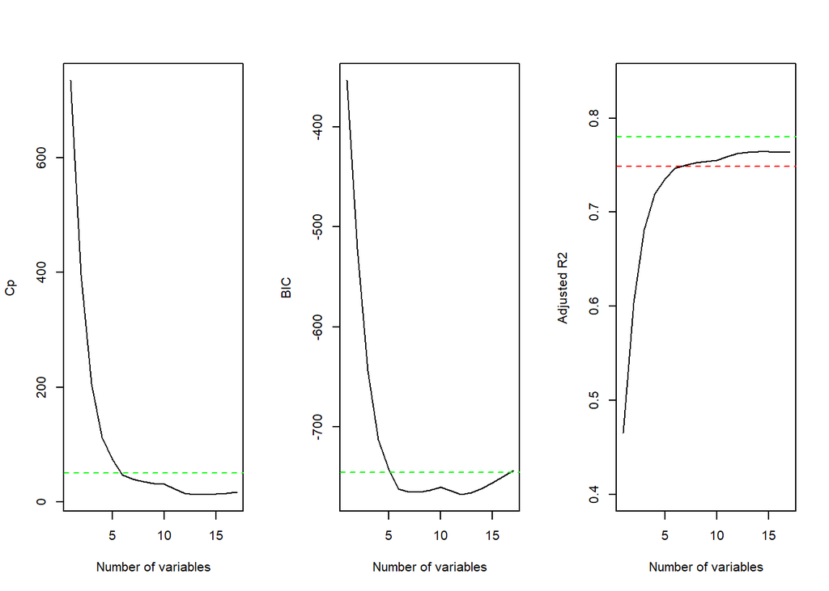

```r
fit <- regsubsets(Outstate ~ ., data = train, nvmax = 17, method = "forward")
fit.summary <- summary(fit)
par(mfrow = c(1, 3))
plot(fit.summary$cp, xlab = "Number of variables", ylab = "Cp", type = "l")
min.cp <- min(fit.summary$cp)
std.cp <- sd(fit.summary$cp)
abline(h = min.cp + 0.2 * std.cp, col = "green", lty = 2)
abline(h = min.cp - 0.2 * std.cp, col = "red", lty = 2)
plot(fit.summary$bic, xlab = "Number of variables", ylab = "BIC", type='l')
min.bic <- min(fit.summary$bic)
std.bic <- sd(fit.summary$bic)
abline(h = min.bic + 0.2 * std.bic, col = "green", lty = 2)
abline(h = min.bic - 0.2 * std.bic, col = "red", lty = 2)
plot(fit.summary$adjr2, xlab = "Number of variables", ylab = "Adjusted R2", type = "l", ylim = c(0.4, 0.84))
max.adjr2 <- max(fit.summary$adjr2)
std.adjr2 <- sd(fit.summary$adjr2)
abline(h = max.adjr2 + 0.2 * std.adjr2, col = "green", lty = 2)
abline(h = max.adjr2 - 0.2 * std.adjr2, col = "red", lty = 2)
```

```r
fit <- regsubsets(Outstate ~ ., data = College, method = "forward")
coeffs <- coef(fit, id = 6)
names(coeffs)
```

```
## [1] "(Intercept)" "PrivateYes"  "Room.Board"  "PhD"         "perc.alumni"
## [6] "Expend"      "Grad.Rate"
```

#Cp, BIC and adjr2 show that size 6 is the minimum size for the subset for which the scores are within 0.2 standard devitations of optimum

#10b:

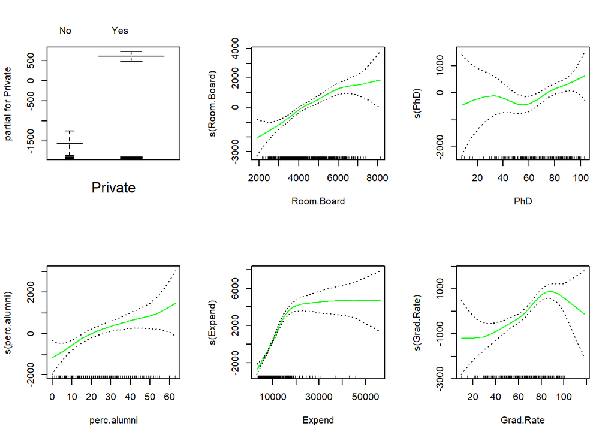

```r
fit1 <- gam(Outstate ~ Private + s(Room.Board) + s(PhD) + s(perc.alumni) + s(Expend) + s(Grad.Rate), data = train)
par(mfrow = c(2, 3))
plot(fit1, se = T, col = "green")
```

#‘Private’ is a categorical variable but is has some relationship with ‘Outstate’

#‘Room.Board’, ‘perc.alumni’ shows close linear relationship with ‘Outstate’

#The remainining varibales don’t show any linear relationship with ‘Outstate’

#Heavy non-linear effect can be seen in case of ‘Expend’ variable

#10c:

```r
preds <- predict(fit1, newdata = test)
mse_nonlinear <- mean((preds - test$Outstate)^2)
fit_lm <- lm(Outstate ~ Private + Room.Board + PhD + perc.alumni + Expend + Grad.Rate, data = train)
preds_linear <- predict(fit_lm, newdata = test)
mse_linear <- mean((preds_linear - test$Outstate)^2)
paste("Non-linear test RMSE:", sqrt(mse_nonlinear))
```

```
## [1] "Non-linear test RMSE: 1939.59578802549"
```

```r
paste("Linear test RMSE:", sqrt(mse_linear))
```

```
## [1] "Linear test RMSE: 1995.64459345352"
```

#The non-linear test RMSE is 1939.5957

#The linear test RMSE is 1995.6445

#The non-linear test RMSE is lower as compared to linear test RMSE

#Even though the magnitude for non-linear is lesser, it is not significantly low so the predictions are not particularly accurate

#10d:

```r
summary(fit1)
```

```
##
## Call: gam(formula = Outstate ~ Private + s(Room.Board) + s(PhD) + s(perc.alumni) +
##     s(Expend) + s(Grad.Rate), data = train)
## Deviance Residuals:
##       Min        1Q    Median        3Q       Max
## -6943.929 -1077.771     7.353  1254.062  7440.450
##
## (Dispersion Parameter for gaussian family taken to be 3373597)
##
##     Null Deviance: 9606335672 on 582 degrees of freedom
## Residual Deviance: 1892589241 on 561.0005 degrees of freedom
## AIC: 10441.41
##
## Number of Local Scoring Iterations: NA
##
## Anova for Parametric Effects
##                 Df     Sum Sq    Mean Sq F value    Pr(>F)
## Private          1 2407617300 2407617300 713.665 < 2.2e-16 ***
## s(Room.Board)    1 1945969515 1945969515 576.823 < 2.2e-16 ***
## s(PhD)           1  577152832  577152832 171.079 < 2.2e-16 ***
## s(perc.alumni)   1  385433395  385433395 114.250 < 2.2e-16 ***
## s(Expend)        1  859790995  859790995 254.859 < 2.2e-16 ***
## s(Grad.Rate)     1  126400688  126400688  37.468 1.747e-09 ***
## Residuals      561 1892589241    3373597
## ---
## Signif. codes:  0 '***' 0.001 '**' 0.01 '*' 0.05 '.' 0.1 ' ' 1
##
## Anova for Nonparametric Effects
##                Npar Df Npar F     Pr(F)
## (Intercept)
## Private
## s(Room.Board)        3  1.745  0.156595
## s(PhD)               3  1.813  0.143576
## s(perc.alumni)       3  0.913  0.434565
## s(Expend)            3 38.574 < 2.2e-16 ***
## s(Grad.Rate)         3  3.951  0.008329 **
## ---
## Signif. codes:  0 '***' 0.001 '**' 0.01 '*' 0.05 '.' 0.1 ' ' 1
```

#ANOVA shows a strong evidence of non-linear relationship between “Outstate” and “Expend”